# Index

### Observation :

- **averagePriceMatched_log** distribution is less likely to normal distribution but it is more normal as compare to **averagePriceMatched** distribution.

### BoxCox Transformation : averagePriceMatched_log

```python
# transform training data & save lambda value
fitted_data_averagePriceMatched, fitted_lambda_averagePriceMatched = stats.boxcox(merged_data['averagePriceMatched'])
```

```python
# fitted_data_averagePriceMatched
```

```python
fitted_lambda_averagePriceMatched
```

```
-1.668065197571059
```

```python
merged_data['averagePriceMatched_boxcox'] = fitted_data_averagePriceMatched
```

```python
describe(merged_data[['averagePriceMatched', 'averagePriceMatched_log','averagePriceMatched_boxcox']]).T
```

```
----------------------
Descriptive statistics
----------------------
```

|  | count | mean | std | min | 25% | 50% | 75% | max | skew | kurt |
| --- | --- | --- | --- | --- | --- | --- | --- | --- | --- | --- |
| averagePriceMatched | 10066.000 | 2.466 | 13.969 | 1.010 | 1.180 | 1.400 | 1.670 | 1000.000 | 43.882 | 2754.245 |
| averagePriceMatched_log | 10066.000 | 0.426 | 0.518 | 0.010 | 0.166 | 0.336 | 0.513 | 6.908 | 4.952 | 33.256 |
| averagePriceMatched_boxcox | 10066.000 | 0.251 | 0.137 | 0.010 | 0.145 | 0.257 | 0.345 | 0.599 | 0.249 | -0.352 |

### Observation :

- **averagePriceMatched_boxcox** have even **lower standard deviation, skew and kurt** as compare to **averagePriceMatched** and **averagePriceMatched**.

```
-------------------------------------------------------
Box Plot and Violin Plot for averagePriceMatched_boxcox
-------------------------------------------------------
```

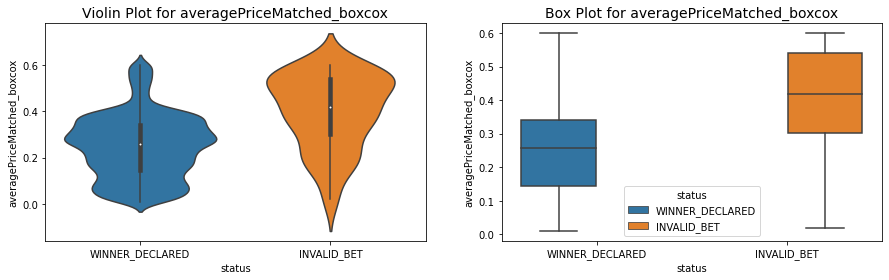

```python
box_violin_plot(merged_data, 'averagePriceMatched_boxcox')
```

### Observation :

- **averagePriceMatched_boxcox** **WINNER_DECLARED** and **INVALID_BET** distribution are **overlapping**.
- Boxplot shows**averagePriceMatched_boxcox** does not shows outlier behavior.

```
--------------------------------------------
Distribution Plot averagePriceMatched_boxcox
--------------------------------------------
```

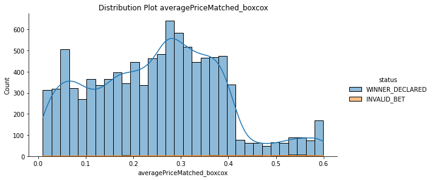

```python
displot(merged_data, 'averagePriceMatched_boxcox')
```

### Observation :

- **averagePriceMatched_boxcox** is more similar to **normal distribution** as compare to **averagePriceMatched** and **averagePriceMatched_log**.

```
----------------------------------------------------------------------------------------------
QQ Plot to check the averagePriceMatched_boxcox distribution is similar to normal distribution
----------------------------------------------------------------------------------------------
```

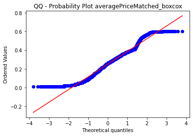

```python
qqPlot(merged_data, 'averagePriceMatched_boxcox')
```

### Observation :

- QQ Plot shows **averagePriceMatched_boxcox** distribution is similar to normal distribution.
- Comparison of QQ plot for **averagePriceMatched_boxcox** and **averagePriceMatched_log** shows **averagePriceMatched_boxcox** is more likely to normal compare to **averagePriceMatched_log**.
- We will include BoxCox transformed feature in modeling.

### Save Lambda's of BoxCox Transform

```python
dict_lambda_boxcox = {}
dict_lambda_boxcox['fitted_lambda_stake'] = fitted_lambda_stake
dict_lambda_boxcox['fitted_lambda_betRate'] = fitted_lambda_betRate
dict_lambda_boxcox['fitted_lambda_averagePriceMatched'] = fitted_lambda_averagePriceMatched
```

```python
dict_lambda_boxcox
```

```
{'fitted_lambda_stake': -0.0466345079709477,
 'fitted_lambda_betRate': -1.6678009857211833,
 'fitted_lambda_averagePriceMatched': -1.668065197571059}
```

```python
import json
with open('dict_lambda_boxcox.json', 'w') as fp:
    json.dump(dict_lambda_boxcox, fp)
```

## 2.5.3 Feature Analysis : placedDate

```python
merged_data['placedDate']
```

```
0        2021-02-22T09:43:04.686Z
1        2021-02-22T09:46:05.458Z
2        2021-02-22T09:36:10.372Z
3        2021-02-22T09:35:32.772Z
4        2021-02-22T09:34:47.648Z
                   ...
10061    2021-02-18T15:39:37.308Z
10062    2021-02-18T15:39:47.201Z
10063    2021-02-18T18:20:17.016Z
10064    2021-02-18T21:01:38.393Z
10065    2021-02-19T21:55:36.789Z
Name: placedDate, Length: 10066, dtype: object
```

#### Convert placedDate dtype to DateTime Format

```python
merged_data['placedDate'].dtype
```

```
dtype('O')
```

```python
now = pd.Timestamp('now')
merged_data['placedDate'] = pd.to_datetime(merged_data['placedDate'], format='%Y-%m-%dT%H:%M:%S.%fZ')
```

```python
merged_data['placedDate'].dtype
```

```
dtype('<M8[ns]')
```

```python
merged_data['placedDate']
```

```
0       2021-02-22 09:43:04.686
1       2021-02-22 09:46:05.458
2       2021-02-22 09:36:10.372
3       2021-02-22 09:35:32.772
4       2021-02-22 09:34:47.648
                  ...
10061   2021-02-18 15:39:37.308
10062   2021-02-18 15:39:47.201
10063   2021-02-18 18:20:17.016
10064   2021-02-18 21:01:38.393
10065   2021-02-19 21:55:36.789
Name: placedDate, Length: 10066, dtype: datetime64[ns]
```

```python
heading('Unique TimeStamps in Data')
merged_data['placedDate'].nunique()
```

```
-------------------------
Unique TimeStamps in Data
-------------------------
```

```
10063
```

## TimeSeries Plot Generated Using Tableau

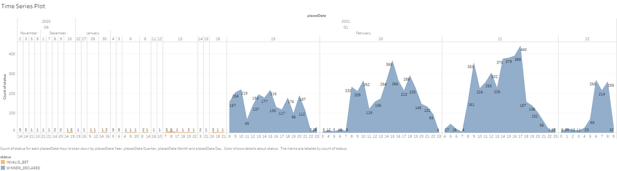

```python
display_image("timeseries.png",width=2000)
```

### Extract information from placeDate TimeStamp

### Extract : Date

```python
merged_data['Date'] = merged_data['placedDate'].dt.date
```

```python
merged_data['Date'].nunique()
```

```
27
```

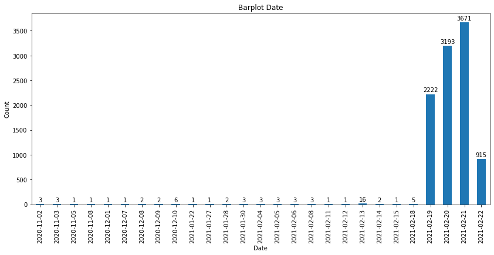

```python
plt.figure(figsize=(14,6))
ax = merged_data['Date'].value_counts().sort_index().plot(kind='bar')
add_value_labels(ax)
plt.title('Barplot Date')
plt.xlabel('Date')
plt.ylabel('Count')
plt.show()
```

### Observation :

- Most of the bets are placed in the **last 4 days i.e. 19, 20, 21 and 22th Feb 2021.**

```python
merged_data.groupby(['Date'])['status'].value_counts().sort_index()
```

```
Date        status
2020-11-02  INVALID_BET           3
2020-11-03  INVALID_BET           3
2020-11-05  INVALID_BET           1
2020-11-08  INVALID_BET           1
2020-12-01  INVALID_BET           1
2020-12-07  INVALID_BET           1
2020-12-08  INVALID_BET           2
2020-12-09  INVALID_BET           2
2020-12-10  INVALID_BET           6
2021-01-22  INVALID_BET           1
2021-01-27  INVALID_BET           1
2021-01-28  INVALID_BET           2
2021-01-30  INVALID_BET           3
2021-02-04  INVALID_BET           3
2021-02-05  INVALID_BET           3
2021-02-06  INVALID_BET           3
2021-02-08  INVALID_BET           3
2021-02-11  INVALID_BET           1
2021-02-12  INVALID_BET           1
2021-02-13  INVALID_BET          16
2021-02-14  INVALID_BET           2
2021-02-15  INVALID_BET           1
2021-02-18  INVALID_BET           5
2021-02-19  INVALID_BET           1
            WINNER_DECLARED    2221
2021-02-20  WINNER_DECLARED    3193
2021-02-21  WINNER_DECLARED    3671
2021-02-22  WINNER_DECLARED     915
Name: status, dtype: int64
```

### Observation :

- ```
  2021-02-19  INVALID_BET           1
              WINNER_DECLARED    2221
  2021-02-20  WINNER_DECLARED    3193
  2021-02-21  WINNER_DECLARED    3671
  2021-02-22  WINNER_DECLARED     915
  ```

  Most of the bets are placed only in these **4 days**.
- Before **'2021-02-19'** all the bets are **INVALID_BET**.
- On **2021-02-13** all bets placed are **INVALID_BET** and it is higher than any other days.

### Extract : Time

```python
merged_data['time'] = merged_data['placedDate'].dt.time
```

```python
merged_data['time']
```

```
0        09:43:04.686000
1        09:46:05.458000
2        09:36:10.372000
3        09:35:32.772000
4        09:34:47.648000
              ...
10061    15:39:37.308000
10062    15:39:47.201000
10063    18:20:17.016000
10064    21:01:38.393000
10065    21:55:36.789000
Name: time, Length: 10066, dtype: object
```

```python
merged_data['time'].nunique()
```

```
10061
```

### Observation :

- 10061 Unique time stamp.
- Cannot use directly for modeling.

### Extract : hour

```python
merged_data['hour'] = merged_data['placedDate'].dt.hour
```

```python
merged_data['hour'].nunique()
```

```
24
```

```
----------------------------
hour grouped by status Count
----------------------------
```

| hour status | 0 | 1 | 2 | 3 | 4 | 5 | 6 | 7 | 8 | 9 | 10 | 11 | 12 | 13 | 14 | 15 | 16 | 17 | 18 | 19 | 20 | 21 | 22 | 23 |
| --- | --- | --- | --- | --- | --- | --- | --- | --- | --- | --- | --- | --- | --- | --- | --- | --- | --- | --- | --- | --- | --- | --- | --- | --- |
| INVALID_BET | 0 | 0 | 0 | 2 | 1 | 3 | 3 | 3 | 11 | 1 | 1 | 0 | 1 | 1 | 11 | 4 | 3 | 1 | 2 | 8 | 3 | 6 | 1 | 0 |
| WINNER_DECLARED | 8 | 20 | 13 | 14 | 52 | 118 | 302 | 226 | 809 | 798 | 705 | 439 | 595 | 592 | 816 | 960 | 785 | 770 | 622 | 461 | 434 | 300 | 107 | 54 |

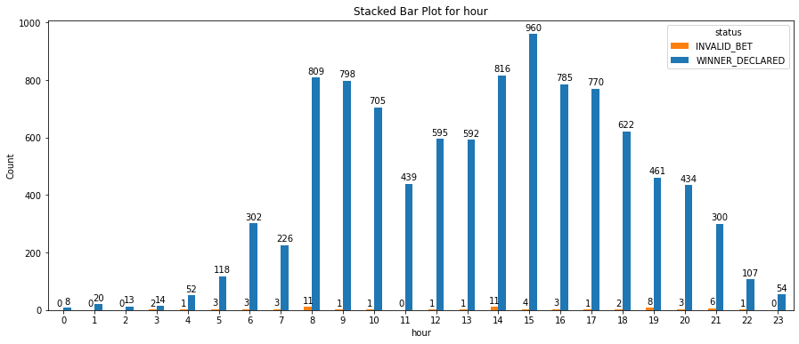

```python
crosstab_by_y_plot(merged_data, 'hour', transposed=True, figsize=(15,6), stacked=False, legend_out=False)
```

### Observation :

- **Distribution of hour** is **bimodal**.
- Most bets are placed at **8 AM** and **3 PM**.

### Extract : week of the year

```python
merged_data['week_of_the_year'] = merged_data['placedDate'].dt.isocalendar().week
```

```python
merged_data['week_of_the_year'].value_counts()
```

```
7     9092
8      915
6       23
50      11
5        9
45       8
4        6
49       1
3        1
Name: week_of_the_year, dtype: Int64
```

```python
merged_data['week_of_the_year'].nunique()
```

```
9
```

```
----------------------------------------
week_of_the_year grouped by status Count
----------------------------------------
```

| status week_of_the_year | INVALID_BET | WINNER_DECLARED |
| --- | --- | --- |
| 3 | 1 | 0 |
| 4 | 6 | 0 |
| 5 | 9 | 0 |
| 6 | 23 | 0 |
| 7 | 7 | 9085 |
| 8 | 0 | 915 |
| 45 | 8 | 0 |
| 49 | 1 | 0 |
| 50 | 11 | 0 |

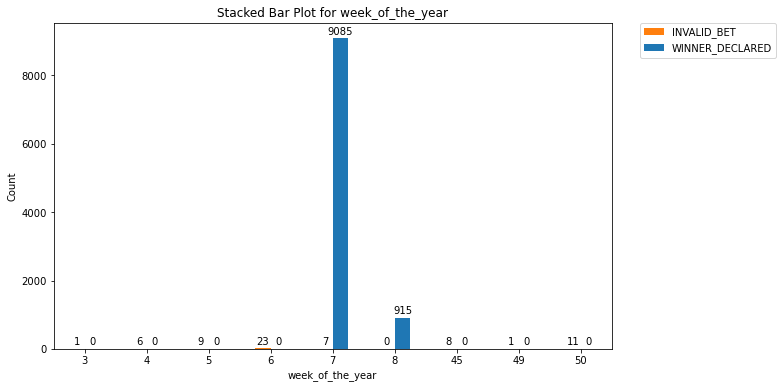

```python
crosstab_by_y_plot(merged_data, 'week_of_the_year', stacked=False, figsize=(10, 6),)
```

### Extract : weekday (7 week days)

```python
merged_data['weekday'] = merged_data['placedDate'].dt.weekday
```

```python
merged_data['weekday'].nunique()
```

```
7
```

```
-------------------------------
weekday grouped by status Count
-------------------------------
```

| status weekday | INVALID_BET | WINNER_DECLARED |
| --- | --- | --- |
| 0 | 8 | 915 |
| 1 | 6 | 0 |
| 2 | 3 | 0 |
| 3 | 18 | 0 |
| 4 | 6 | 2221 |
| 5 | 22 | 3193 |
| 6 | 3 | 3671 |

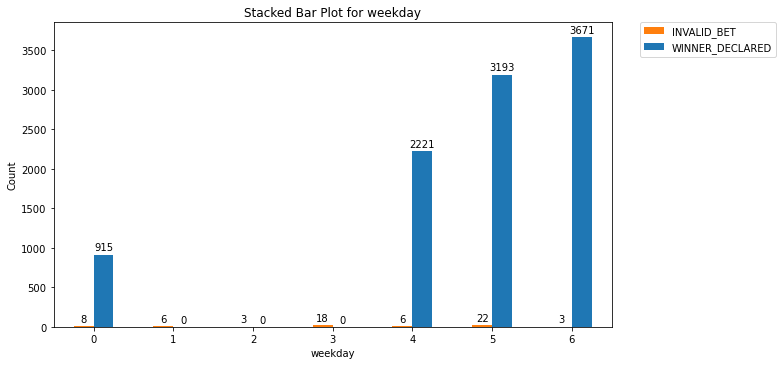

```python
crosstab_by_y_plot(merged_data, 'weekday', stacked=False, figsize=(10, 5.6),)
```

### Observation :

- Here **0** is **Monday** and **6** is **Sunday**.
- Most of the bets are taken place **Sunday, Saturday, Friday, Monday.**

### Save Dataframe

```python
merged_data.to_csv('data_after_EDA.csv',index=False)
```

## 2.6 Correlation Analysis

**Compute pairwise correlation of columns, excluding NA/null values.**

```python
corr = merged_data.corr()
```

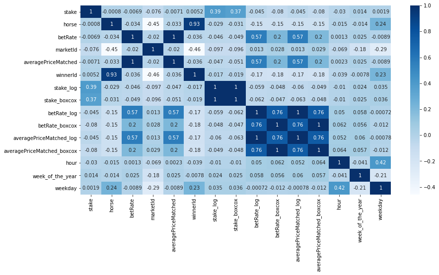

```python
plt.figure(figsize=(14,7))
sns.heatmap(corr, cmap='Blues', annot=True, fmt='.2g',)
plt.show()
```

```python
heading("Top 20 Absolute Correlations")
print(get_top_abs_correlations(corr, 20))
```

```
----------------------------
Top 20 Absolute Correlations
----------------------------
betRate_log              averagePriceMatched_log      1.000
betRate_boxcox           averagePriceMatched_boxcox   1.000
betRate                  averagePriceMatched          1.000
stake_log                stake_boxcox                 1.000
horse                    winnerId                     0.997
betRate_boxcox           averagePriceMatched_log      0.909
averagePriceMatched_log  averagePriceMatched_boxcox   0.909
betRate_log              betRate_boxcox               0.909
                         averagePriceMatched_boxcox   0.909
horse                    marketId                     0.748
marketId                 winnerId                     0.747
averagePriceMatched      betRate_log                  0.719
                         averagePriceMatched_log      0.718
betRate                  betRate_log                  0.718
                         averagePriceMatched_log      0.717
stake                    stake_log                    0.655
                         stake_boxcox                 0.641
hour                     weekday                      0.610
marketId                 weekday                      0.519
winnerId                 betRate_log                  0.499
dtype: float64
```

## 3. Data Standardization

```python
features = list(merged_data.columns.values)
```

```python
merged_data.nunique()
```

```
_id                           10066
stake                           376
type                              2
placedDate                    10063
horse                           319
betRate                         258
marketId                        390
IP                             1070
eventType                         3
userName                        410
selectionName                   318
marketName                       10
event                           245
averagePriceMatched             726
status                            2
winnerId                        195
Details                         222
city                             85
region                           30
country                           9
loc                             105
org                             102
postal                          103
timezone                         10
Latitude                        104
Longitude                       105
stake_log                       376
stake_boxcox                    376
betRate_log                     258
betRate_boxcox                  258
averagePriceMatched_log         721
averagePriceMatched_boxcox      714
Date                             27
time                          10061
hour                             24
week_of_the_year                  9
weekday                           7
dtype: int64
```

```python
merged_data.columns.values
```

```
array(['_id', 'stake', 'type', 'placedDate', 'horse', 'betRate',
       'marketId', 'IP', 'eventType', 'userName', 'selectionName',
       'marketName', 'event', 'averagePriceMatched', 'status', 'winnerId',
       'Details', 'city', 'region', 'country', 'loc', 'org', 'postal',
       'timezone', 'Latitude', 'Longitude', 'stake_log', 'stake_boxcox',
       'betRate_log', 'betRate_boxcox', 'averagePriceMatched_log',
       'averagePriceMatched_boxcox', 'Date', 'time', 'hour',
       'week_of_the_year', 'weekday'], dtype=object)
```

```python
# numerical_fet = ['stake', 'stake_log', 'stake_boxcox', 'betRate', 'betRate_log', 'betRate_boxcox',
#                  'marketId', 'averagePriceMatched', 'averagePriceMatched_log', 'averagePriceMatched_boxcox']

# categorical_fet = ['type', 'horse', 'eventType', 'userName', 'selectionName', 'marketName', 'event', 'winnerId',
#            'IP_version', 'city', 'region', 'country', 'org', 'timezone',
#            'Date', 'hour', 'week', 'weekday']

# dependent_fet = 'status'
```

### 3.1 Dropping useless features based on EDA and Correlation:

[output not shown]

```python
numerical_fet = ['stake_boxcox','betRate_boxcox','marketId', 'averagePriceMatched_boxcox']

categorical_fet = ['type', 'eventType',  'marketName', 'event',
                   'hour', 'week_of_the_year', 'weekday']

dependent_fet = 'status'
```

```python
# merged_data[numerical_fet].head()
```

```python
# merged_data[categorical_fet].head(3)
```

### 3.2 Missing Value Imputation

```python
missing_values_table(merged_data[categorical_fet])
```

```
Dataframe has 7 columns.
There are 0 columns that have missing values.
```

|  | Missing Values | % of Total Values |
| --- | --- | --- |

```python
new_df = pd.concat([merged_data[numerical_fet],
                    merged_data[categorical_fet],
                    merged_data[dependent_fet]], axis=1)
```

```python
# new_df.head(3)
```

```python
missing_values_table(new_df)
```

```
Dataframe has 12 columns.
There are 0 columns that have missing values.
```

|  | Missing Values | % of Total Values |
| --- | --- | --- |

```python
# new_df.info()
```

```python
print(DataFrameImputer.__doc__)
```

```
Impute missing values.

    Columns of dtype object are imputed with the most frequent value (mode)
    in column.

    Columns of other types are imputed with mean of column.
```

```python
data = DataFrameImputer().fit_transform(new_df)
```

```python
data.isnull().sum().any()
```

```
False
```

```python
data.head(3)
```

|  | stake_boxcox | betRate_boxcox | marketId | averagePriceMatched_boxcox | type | eventType | marketName | event | hour | week_of_the_year | weekday | status |
| --- | --- | --- | --- | --- | --- | --- | --- | --- | --- | --- | --- | --- |
| 0 | 5.397 | 0.019 | 1.180 | 0.019 | BACK | Tennis | Match Odds | Saisai Zheng v Danielle Rose Collins | 9 | 8 | 0 | WINNER_DECLARED |
| 1 | 6.434 | 0.010 | 1.180 | 0.010 | LAY | Tennis | Match Odds | Saisai Zheng v Danielle Rose Collins | 9 | 8 | 0 | WINNER_DECLARED |
| 2 | 8.071 | 0.056 | 1.180 | 0.047 | LAY | Tennis | Match Odds | Saisai Zheng v Danielle Rose Collins | 9 | 8 | 0 | WINNER_DECLARED |

```python
data.shape
```

```
(10066, 12)
```

#### Here we does not have any missing value but we keep missing value imputation code, since including some other features what we did not included here have missing values. If we include them this missing value imputation code will be used.

## 3.3 Train-Test spit

```python
from sklearn.model_selection import train_test_split
train, test = train_test_split(data, test_size=0.3, stratify=data['status'], random_state=1)
```

```python
print('Train data shape : ',train.shape)
print('Test data shape : ',test.shape)
```

```
Train data shape :  (7046, 12)
Test data shape :  (3020, 12)
```

```python
train['status'].value_counts()
```

```
WINNER_DECLARED    7000
INVALID_BET          46
Name: status, dtype: int64
```

```python
test['status'].value_counts()
```

```
WINNER_DECLARED    3000
INVALID_BET          20
Name: status, dtype: int64
```

```python
def pie_labeling_train(x):
    print(x)
    return '{:.4f}%\n(#{:.0f})'.format(x, sums_train.values.sum()*x/100)
def pie_labeling_test(x):
    print(x)
    return '{:.4f}%\n(#{:.0f})'.format(x, sums_test.values.sum()*x/100)
```

```
99.34714436531067
0.652852701023221
99.33775067329407
0.6622516550123692
```

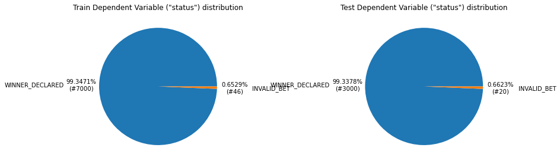

```python
fig = plt.figure(figsize=(24,10))

#this line will produce a figure which has 2 row
#and 4 columns
#(0, 0) specifies the left upper coordinate of your plot
ax1 = plt.subplot2grid((2,4),(0,0))

sums_train = train['status'].value_counts()
plt.pie(sums_train, labels=['WINNER_DECLARED', 'INVALID_BET'],autopct=pie_labeling_train, pctdistance=1.3, labeldistance=1.6)
plt.title('Train Dependent Variable ("status") distribution')

#next one
ax1 = plt.subplot2grid((2, 4), (0, 1))
sums_test = test['status'].value_counts()
plt.pie(sums_test, labels=['WINNER_DECLARED', 'INVALID_BET'],autopct=pie_labeling_test, pctdistance=1.3, labeldistance=1.6)
plt.title('Test Dependent Variable ("status") distribution')

plt.tight_layout()
plt.show()
```

### Observation :

- **Train and Test** set both have **same distribution of dependent variable**.
- Since we have **Imbalance Data**, so we have this **class imbalance in train and test set** too.

#### Encode dependent variable

```python
train = train.replace({'status': {'WINNER_DECLARED':0, 'INVALID_BET':1}})
test = test.replace({'status': {'WINNER_DECLARED':0, 'INVALID_BET':1}})
```

```python
y_train = train['status'].copy()
X_train = train.drop("status",axis=1).copy()
print('X_train shape :',X_train.shape)
print('y_train shape : ',y_train.shape)
```

```
X_train shape : (7046, 11)
y_train shape :  (7046,)
```

```python
y_test=test['status'].copy()
X_test=test.drop("status",axis=1).copy()
print('X_test shape : ',X_test.shape)
print('y_test shape : ',y_test.shape)
```

```
X_test shape :  (3020, 11)
y_test shape :  (3020,)
```

```python
# for i in train.columns:
#     print("{:<40}{:>20}".format(i,train[i].nunique()))
```

## 3.4 Feature Encoding

### For Numerical features

```python
X_train_numerical=X_train[numerical_fet].copy()
X_test_numerical=X_test[numerical_fet].copy()
```

```python
from sklearn.preprocessing import StandardScaler,OneHotEncoder , LabelEncoder ,normalize

scaler = StandardScaler()
scaler.fit(X_train_numerical)
X_train_numerical_std = scaler.transform(X_train_numerical)
X_test_numerical_std = scaler.transform(X_test_numerical)
```

```python
X_train_numerical_std=pd.DataFrame(X_train_numerical_std,columns=numerical_fet)
X_test_numerical_std=pd.DataFrame(X_test_numerical_std,columns=numerical_fet)
```

```python
# Checking the values after converting
X_train_numerical_std.head()
```

|  | stake_boxcox | betRate_boxcox | marketId | averagePriceMatched_boxcox |
| --- | --- | --- | --- | --- |
| 0 | -1.401 | 0.313 | 0.778 | 0.386 |
| 1 | 0.122 | 1.089 | -0.105 | 1.087 |
| 2 | -0.048 | -1.193 | 0.723 | -1.189 |
| 3 | -0.652 | 1.025 | 0.087 | 1.023 |
| 4 | -0.968 | -1.431 | 0.781 | -1.427 |

```python
print("Shape of Standardized X_train: ",X_train_numerical_std.shape)
print("Shape of Standardized X_test: ",X_test_numerical_std.shape)
```

```
Shape of Standardized X_train:  (7046, 4)
Shape of Standardized X_test:  (3020, 4)
```

#### Dump StandardScaler

```python
import joblib
joblib.dump(scaler, 'scaler.joblib')
```

```
['scaler.joblib']
```

### For Categorical Features

```python
X_train_categorical=X_train[categorical_fet].copy()
X_test_categorical=X_test[categorical_fet].copy()
X_train_categorical.head()
```

|  | type | eventType | marketName | event | hour | week_of_the_year | weekday |
| --- | --- | --- | --- | --- | --- | --- | --- |
| 3134 | BACK | Cricket | Match Odds | Warriors v Dolphins | 13 | 7 | 6 |
| 9132 | LAY | Cricket | Match Odds | Dolphins v Cape Cobras | 13 | 7 | 4 |
| 7384 | LAY | Tennis | Match Odds | Brady v Osaka | 9 | 7 | 5 |
| 2392 | BACK | Soccer | Over/Under 3.5 Goals | Aston Villa v Leicester | 15 | 7 | 6 |
| 3869 | LAY | Tennis | Match Odds | Djokovic v Medvedev | 10 | 7 | 6 |

```python
onehot_encoder = OneHotEncoder(sparse=False, handle_unknown = 'ignore')
X_train_categorical_encoded = onehot_encoder.fit(X_train_categorical)
X_train_categorical_encoded = onehot_encoder.transform(X_train_categorical)
X_test_categorical_encoded = onehot_encoder.transform(X_test_categorical)
```

```python
# Checking the Encoded Data
X_train_categorical_encoded
```

```
array([[1., 0., 1., ..., 0., 0., 1.],
       [0., 1., 1., ..., 1., 0., 0.],
       [0., 1., 0., ..., 0., 1., 0.],
       ...,
       [0., 1., 0., ..., 1., 0., 0.],
       [0., 1., 0., ..., 0., 1., 0.],
       [0., 1., 1., ..., 0., 0., 1.]])
```

```python
print("X_train after One Hot Encoding: ",X_train_categorical_encoded.shape)
print("X_test after One Hot Encoding: ",X_test_categorical_encoded.shape)
```

```
X_train after One Hot Encoding:  (7046, 281)
X_test after One Hot Encoding:  (3020, 281)
```

```python
## Obtaining Feature Names from the Classifier
# list(onehot_encoder.get_feature_names(categorical_fet))
```

```python
encodedCatColumnNames = list(onehot_encoder.get_feature_names(categorical_fet))
X_train_categorical_encoded=pd.DataFrame(X_train_categorical_encoded,columns=encodedCatColumnNames)
X_test_categorical_encoded=pd.DataFrame(X_test_categorical_encoded,columns=encodedCatColumnNames)
```

```python
X_train_categorical_encoded.head(3)
```

|  | type_BACK | type_LAY | eventType_Cricket | eventType_Soccer | eventType_Tennis | marketName_Match Odds | marketName_Over/Under 0.5 Goals | marketName_Over/Under 1.5 Goals | marketName_Over/Under 2.5 Goals | marketName_Over/Under 3.5 Goals | marketName_Over/Under 4.5 Goals | marketName_Over/Under 5.5 Goals | marketName_Over/Under 6.5 Goals | marketName_Over/Under 7.5 Goals | marketName_Tied Match | event_AAB v Midtjylland | event_AC Horsens v OB | event_AC Milan v Inter | event_Accrington v Shrewsbury | event_Adelaide United v Central Coast Mariners | event_Admira Wacker v LASK Linz | event_Ajax v Sparta Rotterdam | event_Albacete v Sporting Gijon | event_Altmaier v Martin | event_Amiens v Sochaux | event_Arminia Bielefeld v Wolfsburg | event_Arsenal v Man City | event_Ascoli v Salernitana | event_Aston Villa v Leicester | … |
| --- | --- | --- | --- | --- | --- | --- | --- | --- | --- | --- | --- | --- | --- | --- | --- | --- | --- | --- | --- | --- | --- | --- | --- | --- | --- | --- | --- | --- | --- | --- |
| 0 | 1.000 | 0.000 | 1.000 | 0.000 | 0.000 | 1.000 | 0.000 | 0.000 | 0.000 | 0.000 | 0.000 | 0.000 | 0.000 | 0.000 | 0.000 | 0.000 | 0.000 | 0.000 | 0.000 | 0.000 | 0.000 | 0.000 | 0.000 | 0.000 | 0.000 | 0.000 | 0.000 | 0.000 | 0.000 | … |
| 1 | 0.000 | 1.000 | 1.000 | 0.000 | 0.000 | 1.000 | 0.000 | 0.000 | 0.000 | 0.000 | 0.000 | 0.000 | 0.000 | 0.000 | 0.000 | 0.000 | 0.000 | 0.000 | 0.000 | 0.000 | 0.000 | 0.000 | 0.000 | 0.000 | 0.000 | 0.000 | 0.000 | 0.000 | 0.000 | … |
| 2 | 0.000 | 1.000 | 0.000 | 0.000 | 1.000 | 1.000 | 0.000 | 0.000 | 0.000 | 0.000 | 0.000 | 0.000 | 0.000 | 0.000 | 0.000 | 0.000 | 0.000 | 0.000 | 0.000 | 0.000 | 0.000 | 0.000 | 0.000 | 0.000 | 0.000 | 0.000 | 0.000 | 0.000 | 0.000 | … |

```python
X_train_categorical_encoded.shape
```

```
(7046, 281)
```

#### Dump OneHot Encoder

```python
import joblib
joblib.dump(onehot_encoder, 'onehot_encoder.joblib')
```

```
['onehot_encoder.joblib']
```

## 4. Feature Selection

### 4.1 For Numerical Data

```python
from sklearn.feature_selection import SelectKBest,f_classif,chi2
```

```python
n = SelectKBest(score_func=f_classif,k='all')
numcols = n.fit(X_train_numerical_std,y_train)
```

```python
X_train_numerical_std.shape
```

```
(7046, 4)
```

```python
top_fet={}

## https://machinelearningmastery.com/feature-selection-with-categorical-data/
for i in range(len(n.scores_)):
    top_fet[numerical_fet[i]]=n.scores_[i]

top_fet = sorted(top_fet.items(), key=lambda x: x[1],reverse=True)
top_fet = dict(top_fet)

for key, value in top_fet.items():
    print('{:<40}|{:>20}'.format(key, value))
```

```
marketId                                |   56.77709060822096
averagePriceMatched_boxcox              |   53.33128448211988
betRate_boxcox                          |   50.96758568112809
stake_boxcox                            |  13.844882091182718
```

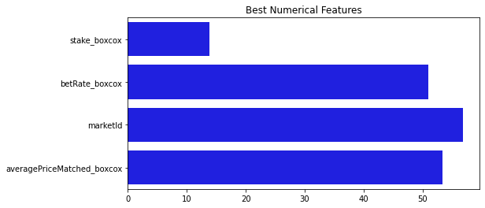

```python
plt.figure(figsize=(8, 4))
sns.barplot(x=numcols.scores_, y=numerical_fet, color = 'b')
plt.title('Best Numerical Features')
plt.show()
```

### Observation :

- Since we have only 4 numerical features, and all of them are we are going to use.

### 4.2 For Categorical Data

```python
c = SelectKBest(score_func=chi2)
numcols=c.fit(X_train_categorical_encoded,y_train)
```

```python
top_fet={}

## https://machinelearningmastery.com/feature-selection-with-categorical-data/
for i in range(len(c.scores_)):
    top_fet[encodedCatColumnNames[i]]=c.scores_[i]

top_fet = sorted(top_fet.items(), key=lambda x: x[1],reverse=True)
top_fet = dict(top_fet)

# for key, value in top_fet.items():
#     print('{:<40}|{:>20}'.format(key, value))
```

```python
top_cat = pd.DataFrame(zip(*sorted(zip(numcols.scores_, encodedCatColumnNames), reverse=True))).T
```

```python
print('Top 10 Categorial Feature')
top_cat.columns = ['score', 'name']
top_cat.head(10)
```

```
Top 10 Categorial Feature
```

|  | score | name |
| --- | --- | --- |
| 0 | 2891.304 | week_of_the_year_6 |
| 1 | 1978.261 | weekday_3 |
| 2 | 1673.913 | event_Bangladesh v West Indies |
| 3 | 1369.565 | week_of_the_year_5 |
| 4 | 760.870 | week_of_the_year_50 |
| 5 | 760.870 | week_of_the_year_4 |
| 6 | 608.696 | event_Pakistan v South Africa |
| 7 | 456.522 | week_of_the_year_45 |
| 8 | 456.522 | event_Central Districts v Canterbury |
| 9 | 456.522 | event_Casanova v Dellien |

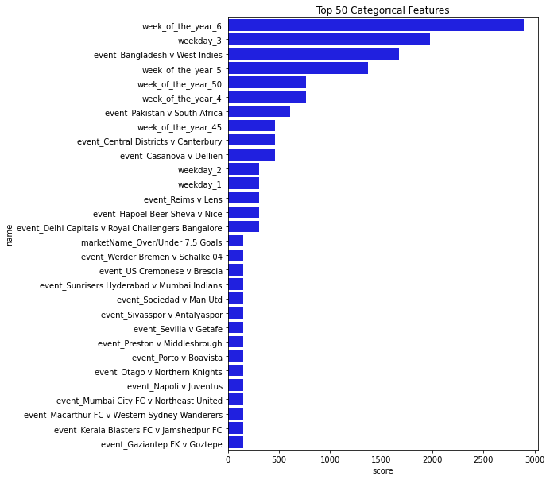

```python
plt.figure(figsize=(7,10))
sns.barplot(x=top_cat['score'].iloc[:30],y=top_cat['name'][:30], color='b')
plt.title('Top 50 Categorical Features')
plt.show()
```

## 5. Build Data Matrix for Models

```python
X_train_merged = pd.concat([X_train_numerical_std,X_train_categorical_encoded], axis=1)
X_test_merged = pd.concat([X_test_numerical_std,X_test_categorical_encoded], axis=1)
```

```python
X_train_merged.head()
```

|  | stake_boxcox | betRate_boxcox | marketId | averagePriceMatched_boxcox | type_BACK | type_LAY | eventType_Cricket | eventType_Soccer | eventType_Tennis | marketName_Match Odds | marketName_Over/Under 0.5 Goals | marketName_Over/Under 1.5 Goals | marketName_Over/Under 2.5 Goals | marketName_Over/Under 3.5 Goals | marketName_Over/Under 4.5 Goals | marketName_Over/Under 5.5 Goals | marketName_Over/Under 6.5 Goals | marketName_Over/Under 7.5 Goals | marketName_Tied Match | event_AAB v Midtjylland | event_AC Horsens v OB | event_AC Milan v Inter | event_Accrington v Shrewsbury | event_Adelaide United v Central Coast Mariners | event_Admira Wacker v LASK Linz | event_Ajax v Sparta Rotterdam | event_Albacete v Sporting Gijon | event_Altmaier v Martin | event_Amiens v Sochaux | … |
| --- | --- | --- | --- | --- | --- | --- | --- | --- | --- | --- | --- | --- | --- | --- | --- | --- | --- | --- | --- | --- | --- | --- | --- | --- | --- | --- | --- | --- | --- | --- |
| 0 | -1.401 | 0.313 | 0.778 | 0.386 | 1.000 | 0.000 | 1.000 | 0.000 | 0.000 | 1.000 | 0.000 | 0.000 | 0.000 | 0.000 | 0.000 | 0.000 | 0.000 | 0.000 | 0.000 | 0.000 | 0.000 | 0.000 | 0.000 | 0.000 | 0.000 | 0.000 | 0.000 | 0.000 | 0.000 | … |
| 1 | 0.122 | 1.089 | -0.105 | 1.087 | 0.000 | 1.000 | 1.000 | 0.000 | 0.000 | 1.000 | 0.000 | 0.000 | 0.000 | 0.000 | 0.000 | 0.000 | 0.000 | 0.000 | 0.000 | 0.000 | 0.000 | 0.000 | 0.000 | 0.000 | 0.000 | 0.000 | 0.000 | 0.000 | 0.000 | … |
| 2 | -0.048 | -1.193 | 0.723 | -1.189 | 0.000 | 1.000 | 0.000 | 0.000 | 1.000 | 1.000 | 0.000 | 0.000 | 0.000 | 0.000 | 0.000 | 0.000 | 0.000 | 0.000 | 0.000 | 0.000 | 0.000 | 0.000 | 0.000 | 0.000 | 0.000 | 0.000 | 0.000 | 0.000 | 0.000 | … |
| 3 | -0.652 | 1.025 | 0.087 | 1.023 | 1.000 | 0.000 | 0.000 | 1.000 | 0.000 | 0.000 | 0.000 | 0.000 | 0.000 | 1.000 | 0.000 | 0.000 | 0.000 | 0.000 | 0.000 | 0.000 | 0.000 | 0.000 | 0.000 | 0.000 | 0.000 | 0.000 | 0.000 | 0.000 | 0.000 | … |
| 4 | -0.968 | -1.431 | 0.781 | -1.427 | 0.000 | 1.000 | 0.000 | 0.000 | 1.000 | 1.000 | 0.000 | 0.000 | 0.000 | 0.000 | 0.000 | 0.000 | 0.000 | 0.000 | 0.000 | 0.000 | 0.000 | 0.000 | 0.000 | 0.000 | 0.000 | 0.000 | 0.000 | 0.000 | 0.000 | … |

```python
X_test_merged.head()
```

|  | stake_boxcox | betRate_boxcox | marketId | averagePriceMatched_boxcox | type_BACK | type_LAY | eventType_Cricket | eventType_Soccer | eventType_Tennis | marketName_Match Odds | marketName_Over/Under 0.5 Goals | marketName_Over/Under 1.5 Goals | marketName_Over/Under 2.5 Goals | marketName_Over/Under 3.5 Goals | marketName_Over/Under 4.5 Goals | marketName_Over/Under 5.5 Goals | marketName_Over/Under 6.5 Goals | marketName_Over/Under 7.5 Goals | marketName_Tied Match | event_AAB v Midtjylland | event_AC Horsens v OB | event_AC Milan v Inter | event_Accrington v Shrewsbury | event_Adelaide United v Central Coast Mariners | event_Admira Wacker v LASK Linz | event_Ajax v Sparta Rotterdam | event_Albacete v Sporting Gijon | event_Altmaier v Martin | event_Amiens v Sochaux | … |
| --- | --- | --- | --- | --- | --- | --- | --- | --- | --- | --- | --- | --- | --- | --- | --- | --- | --- | --- | --- | --- | --- | --- | --- | --- | --- | --- | --- | --- | --- | --- |
| 0 | 0.331 | 0.498 | 0.120 | 0.498 | 1.000 | 0.000 | 0.000 | 1.000 | 0.000 | 1.000 | 0.000 | 0.000 | 0.000 | 0.000 | 0.000 | 0.000 | 0.000 | 0.000 | 0.000 | 0.000 | 0.000 | 0.000 | 0.000 | 0.000 | 0.000 | 0.000 | 0.000 | 0.000 | 0.000 | … |
| 1 | -0.170 | -1.694 | 0.778 | -1.689 | 0.000 | 1.000 | 1.000 | 0.000 | 0.000 | 1.000 | 0.000 | 0.000 | 0.000 | 0.000 | 0.000 | 0.000 | 0.000 | 0.000 | 0.000 | 0.000 | 0.000 | 0.000 | 0.000 | 0.000 | 0.000 | 0.000 | 0.000 | 0.000 | 0.000 | … |
| 2 | -1.401 | -0.181 | 0.894 | -0.179 | 0.000 | 1.000 | 0.000 | 0.000 | 1.000 | 1.000 | 0.000 | 0.000 | 0.000 | 0.000 | 0.000 | 0.000 | 0.000 | 0.000 | 0.000 | 0.000 | 0.000 | 0.000 | 0.000 | 0.000 | 0.000 | 0.000 | 0.000 | 0.000 | 0.000 | … |
| 3 | 2.008 | -1.431 | -1.860 | -1.427 | 1.000 | 0.000 | 1.000 | 0.000 | 0.000 | 1.000 | 0.000 | 0.000 | 0.000 | 0.000 | 0.000 | 0.000 | 0.000 | 0.000 | 0.000 | 0.000 | 0.000 | 0.000 | 0.000 | 0.000 | 0.000 | 0.000 | 0.000 | 0.000 | 0.000 | … |
| 4 | 0.331 | -1.431 | 0.781 | -1.427 | 0.000 | 1.000 | 0.000 | 0.000 | 1.000 | 1.000 | 0.000 | 0.000 | 0.000 | 0.000 | 0.000 | 0.000 | 0.000 | 0.000 | 0.000 | 0.000 | 0.000 | 0.000 | 0.000 | 0.000 | 0.000 | 0.000 | 0.000 | 0.000 | 0.000 | … |

```python
print(X_train_merged.shape)
print(X_test_merged.shape)
```

```
(7046, 285)
(3020, 285)
```

## 6. TSNE Visualization

```python
%%time
from sklearn.manifold import TSNE
tsne2d = TSNE(
    n_components=2,
    perplexity=30.0, # Default
    init='random', # pca
    random_state=101,
    method='barnes_hut',
    n_iter=1000,
    verbose=2,
    angle=0.5
).fit_transform(X_train_merged)
```

```
[t-SNE] Computing 91 nearest neighbors...
[t-SNE] Indexed 7046 samples in 0.797s...
[t-SNE] Computed neighbors for 7046 samples in 16.371s...
[t-SNE] Computed conditional probabilities for sample 1000 / 7046
[t-SNE] Computed conditional probabilities for sample 2000 / 7046
[t-SNE] Computed conditional probabilities for sample 3000 / 7046
[t-SNE] Computed conditional probabilities for sample 4000 / 7046
[t-SNE] Computed conditional probabilities for sample 5000 / 7046
[t-SNE] Computed conditional probabilities for sample 6000 / 7046
[t-SNE] Computed conditional probabilities for sample 7000 / 7046
[t-SNE] Computed conditional probabilities for sample 7046 / 7046
[t-SNE] Mean sigma: 0.810653
[t-SNE] Computed conditional probabilities in 0.333s
[t-SNE] Iteration 50: error = 89.7203979, gradient norm = 0.0320344 (50 iterations in 3.800s)
[t-SNE] Iteration 100: error = 74.5082397, gradient norm = 0.0058877 (50 iterations in 3.224s)
[t-SNE] Iteration 150: error = 71.4324188, gradient norm = 0.0031802 (50 iterations in 3.096s)
[t-SNE] Iteration 200: error = 70.0495529, gradient norm = 0.0021631 (50 iterations in 3.078s)
[t-SNE] Iteration 250: error = 69.2367172, gradient norm = 0.0017376 (50 iterations in 3.129s)
[t-SNE] KL divergence after 250 iterations with early exaggeration: 69.236717
[t-SNE] Iteration 300: error = 2.0232878, gradient norm = 0.0014130 (50 iterations in 3.225s)
[t-SNE] Iteration 350: error = 1.4106592, gradient norm = 0.0006168 (50 iterations in 3.151s)
[t-SNE] Iteration 400: error = 1.1314011, gradient norm = 0.0003657 (50 iterations in 4.316s)
[t-SNE] Iteration 450: error = 0.9787596, gradient norm = 0.0002395 (50 iterations in 3.543s)
[t-SNE] Iteration 500: error = 0.8841934, gradient norm = 0.0001754 (50 iterations in 3.241s)
[t-SNE] Iteration 550: error = 0.8209775, gradient norm = 0.0001379 (50 iterations in 3.199s)
[t-SNE] Iteration 600: error = 0.7766211, gradient norm = 0.0001165 (50 iterations in 3.155s)
[t-SNE] Iteration 650: error = 0.7450615, gradient norm = 0.0000984 (50 iterations in 3.651s)
[t-SNE] Iteration 700: error = 0.7225347, gradient norm = 0.0000911 (50 iterations in 3.177s)
[t-SNE] Iteration 750: error = 0.7064455, gradient norm = 0.0000833 (50 iterations in 3.173s)
[t-SNE] Iteration 800: error = 0.6953197, gradient norm = 0.0000790 (50 iterations in 3.482s)
[t-SNE] Iteration 850: error = 0.6873947, gradient norm = 0.0000738 (50 iterations in 3.517s)
[t-SNE] Iteration 900: error = 0.6811014, gradient norm = 0.0000684 (50 iterations in 3.905s)
[t-SNE] Iteration 950: error = 0.6760705, gradient norm = 0.0000677 (50 iterations in 4.091s)
[t-SNE] Iteration 1000: error = 0.6714608, gradient norm = 0.0000626 (50 iterations in 3.389s)
[t-SNE] KL divergence after 1000 iterations: 0.671461
Wall time: 1min 26s
```

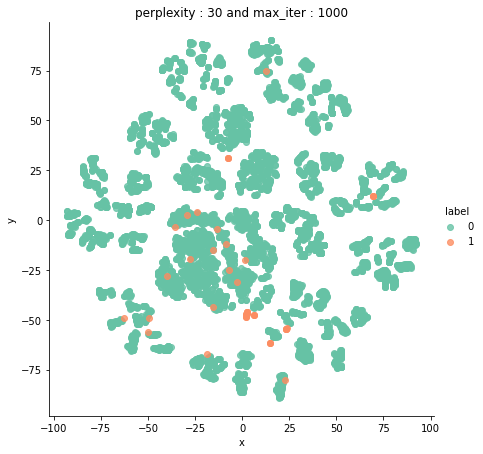

```python
y_ = y_train.values
df = pd.DataFrame({'x':tsne2d[:,0], 'y':tsne2d[:,1] ,'label':y_})

# draw the plot in appropriate place in the grid
sns.lmplot(data=df, x='x', y='y', hue='label', fit_reg=False, height=6,palette="Set2",)
plt.title("perplexity : {} and max_iter : {}".format(30, 1000))
plt.show()
```

### Observation :

- TSNE plot shows **class '0' (WINNER_DECLARED)** is forming **many small clusters**,
  - forming cluster and separate cluster is good for prediction of this class.
- TSNE plot shows **class '1' (INVALID_BET)** is **not forming any clusters**,
  - it is **distributed** along with the **WINNER_DECLARED** class.
  - it **because** of data have **very less points** for the **INVALID_BET** class.
- TSNE plot shows **class '0' (WINNER_DECLARED) and class '1' (INVALID_BET)** are **overlapping on some points**.

## 7. Models

```python
# This function plots the confusion matrices.
def plot_confusion_matrix(test_y, predict_y):
    """
    plot_confusion_matrix(test_y, predict_y)
        : plot confusion, precision, recall heatmap.
    test_y : ground truth y values.
    predict_y : predicted y values.
    """

    C = confusion_matrix(test_y, predict_y)
    A =(((C.T)/(C.sum(axis=1))).T)
    B =(C/C.sum(axis=0))
    plt.figure(figsize=(16,4))

    labels = [0,1]

    plt.subplot(1, 3, 1)
    sns.heatmap(C, annot=True, fmt=".3f", xticklabels=labels, yticklabels=labels,cmap="Blues")
    plt.xlabel('Predicted Class')
    plt.ylabel('Original Class')
    plt.title("Confusion matrix")

    plt.subplot(1, 3, 2)
    sns.heatmap(B, annot=True, fmt=".3f", xticklabels=labels, yticklabels=labels,cmap="Reds")
    plt.xlabel('Predicted Class')
    plt.ylabel('Original Class')
    plt.title("Precision matrix")

    plt.subplot(1, 3, 3)
    sns.heatmap(A, annot=True, fmt=".3f", xticklabels=labels, yticklabels=labels,cmap="Greens")
    plt.xlabel('Predicted Class')
    plt.ylabel('Original Class')
    plt.title("Recall matrix")

    plt.show()
```

```python
from sklearn.metrics.classification import accuracy_score, log_loss
from sklearn.metrics import confusion_matrix
```

```python
from sklearn.model_selection import GridSearchCV , train_test_split
from sklearn.model_selection import train_test_split
from sklearn.model_selection import train_test_split,KFold,cross_val_score
from sklearn.linear_model import LogisticRegression
from sklearn.metrics import accuracy_score , f1_score , make_scorer
from sklearn.preprocessing import StandardScaler,OneHotEncoder , LabelEncoder ,normalize
from sklearn.feature_selection import SelectKBest,f_classif,chi2
from sklearn.metrics.classification import accuracy_score, log_loss
from sklearn.metrics import confusion_matrix
from sklearn.linear_model import SGDClassifier
from sklearn.calibration import CalibratedClassifierCV
from sklearn.ensemble import RandomForestClassifier
from sklearn.tree import DecisionTreeClassifier
from sklearn.linear_model import LogisticRegression
from sklearn.ensemble import RandomForestClassifier
from sklearn.neighbors import KNeighborsClassifier
from xgboost import XGBClassifier

from sklearn.metrics import roc_auc_score,accuracy_score,precision_score,recall_score,f1_score
from sklearn.metrics import confusion_matrix, roc_curve, auc
```

## 7.1 Machine Learning Models

## 7.1.1 Random Model

```python
test_len = len(y_test)
```

```python
predicted_y = np.zeros((test_len,2))
for i in range(test_len):
    rand_probs = np.random.rand(1,2)
    predicted_y[i] = ((rand_probs/sum(sum(rand_probs)))[0])
```

```
Log loss on Test Data using Random Model :  0.8823688615376248
Accuracy on Test Data using Random Model :  0.5016556291390728
```

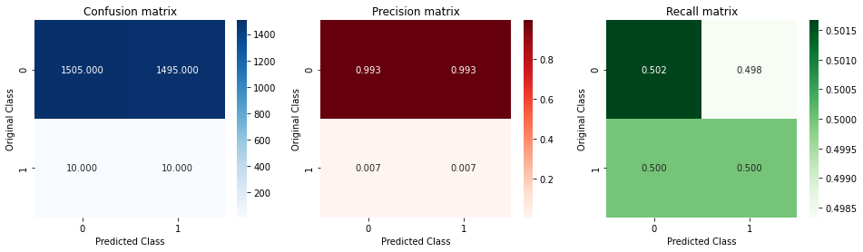

```python
print("Log loss on Test Data using Random Model : ",log_loss(y_test, predicted_y, eps=1e-15))
print("Accuracy on Test Data using Random Model : ",accuracy_score(y_test, predicted_y[:,1].round()))

predicted_y =np.argmax(predicted_y, axis=1)
plot_confusion_matrix(y_test, predicted_y)
```

## 7.1.2 Logistic Regression (SGD) with Hyperparameter Tuning

```python
alpha = [10 ** x for x in range(-5, 5)] # hyperparam for SGD classifier.

log_error_array=[]
for i in alpha:
    clf = SGDClassifier(alpha=i, penalty='l2', loss='log', random_state=42,class_weight="balanced")
    clf.fit(X_train_merged, y_train)
    sig_clf = CalibratedClassifierCV(clf, method="sigmoid")
    sig_clf.fit(X_train_merged, y_train)
    predict_y = sig_clf.predict_proba(X_test_merged)
    log_error_array.append(log_loss(y_test, predict_y, labels=clf.classes_, eps=1e-15))
    print('For values of alpha = ', i, "The log loss is:",log_loss(y_test, predict_y, labels=clf.classes_, eps=1e-15))
```

```
For values of alpha =  1e-05 The log loss is: 0.0038003967310407173
For values of alpha =  0.0001 The log loss is: 0.003940539977052907
For values of alpha =  0.001 The log loss is: 0.004465209138230226
For values of alpha =  0.01 The log loss is: 0.005382347501666373
For values of alpha =  0.1 The log loss is: 0.007907343496749052
For values of alpha =  1 The log loss is: 0.015124555851035138
For values of alpha =  10 The log loss is: 0.018434823601526217
For values of alpha =  100 The log loss is: 0.018885417145215463
For values of alpha =  1000 The log loss is: 0.01884200701542584
For values of alpha =  10000 The log loss is: 0.018785643196478338
```

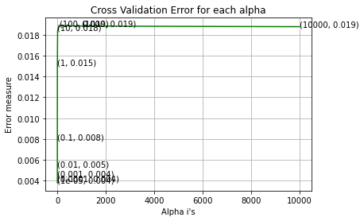

```python
fig, ax = plt.subplots()
ax.plot(alpha, log_error_array,c='g')
for i, txt in enumerate(np.round(log_error_array,3)):
    ax.annotate((alpha[i],np.round(txt,3)), (alpha[i],log_error_array[i]))
plt.grid()
plt.title("Cross Validation Error for each alpha")
plt.xlabel("Alpha i's")
plt.ylabel("Error measure")
plt.rcParams["figure.figsize"] = [10,7]
plt.show()
```

```python
best_alpha = np.argmin(log_error_array)
alpha[best_alpha]
```

```
1e-05
```

```python
best_alpha = np.argmin(log_error_array)
clf = SGDClassifier(alpha=alpha[best_alpha], penalty='l2', loss='log', random_state=42)
clf.fit(X_train_merged, y_train)
sig_clf = CalibratedClassifierCV(clf, method="sigmoid")
sig_clf.fit(X_train_merged, y_train)

predict_y = sig_clf.predict_proba(X_train_merged)
print('For values of best alpha = ', alpha[best_alpha], "The train log loss is:",log_loss(y_train, predict_y, labels=clf.classes_, eps=1e-15))
predict_y = sig_clf.predict_proba(X_test_merged)
print('For values of best alpha = ', alpha[best_alpha], "The test log loss is:",log_loss(y_test, predict_y, labels=clf.classes_, eps=1e-15))
predicted_y =np.argmax(predict_y,axis=1)
print("Accuracy :", accuracy_score(y_test,predicted_y)*100)
plot_confusion_matrix(y_test, predicted_y)
```

[output not shown]

```
For values of best alpha =  1e-05 The train log loss is: 0.0028172964849306208
For values of best alpha =  1e-05 The test log loss is: 0.0034779763217249785
Accuracy : 99.96688741721854
```

### Observation :

- **Logistic Regression (SGD) with hyperparameter tuning** :
  - **Accuracy ≈ 99.96%** which is higher than **Random Model**.

```python
accuracy = {}
roc_r = {}

def train_model(model, name):
    # Checking accuracy
    model = model.fit(X_train_merged, y_train)
    pred = model.predict(X_test_merged)
    acc = accuracy_score(y_test, pred)*100
    accuracy[model] = acc
    print('accuracy_score',acc)
    print('precision_score',precision_score(y_test, pred)*100)
    print('recall_score',recall_score(y_test, pred)*100)
    print('f1_score',f1_score(y_test, pred)*100)
    roc_score = roc_auc_score(y_test, pred)*100
    roc_r[model] = roc_score
    print('roc_auc_score',roc_score)
    # confusion matrix
    print('confusion_matrix')
    plot_confusion_matrix(y_test,pred)
    fpr, tpr, threshold = roc_curve(y_test, pred)
    roc_auc = auc(fpr, tpr)*100

    plt.figure(figsize=(4,4))
    plt.title('Receiver Operating Characteristic')
    plt.plot(fpr, tpr, 'b', label = 'AUC = %0.2f' % roc_auc)
    plt.legend(loc = 'lower right')
    plt.plot([0, 1], [0, 1],'r--')
    plt.xlim([0, 1])
    plt.ylim([0, 1])
    plt.ylabel('True Positive Rate')
    plt.xlabel('False Positive Rate')

    plt.show()


    import _pickle as cPickle
    # save the classifier
    with open(str(name)+'.pkl', 'wb') as fid:
        cPickle.dump(model, fid)

    return model

#     # load it again
#     with open('my_dumped_classifier.pkl', 'rb') as fid:
#         gnb_loaded = cPickle.load(fid)
```

## 7.1.3 Logistic Regression (Sklearn)

```python
lr = LogisticRegression(C=5.0,class_weight="balanced", max_iter= 10000)
train_model(lr, 'log_reg_sklern')
```

[output not shown]

```
accuracy_score 99.96688741721854
precision_score 100.0
recall_score 95.0
f1_score 97.43589743589743
roc_auc_score 97.5
confusion_matrix
```

```
LogisticRegression(C=5.0, class_weight='balanced', max_iter=10000)
```

### Observation :

- **Logistic Regression SkLearn** :
  - **Accuracy ≈ 99.96%**.
  - **High Recall** for **minor class (INVALID_BET)** as compare to **Random Model**.
  - **AUC ≈ 97.5%**

## 7.1.4 KNN (K-Nearest Neighbors)

```
accuracy_score 99.76821192052981
precision_score 100.0
recall_score 65.0
f1_score 78.7878787878788
roc_auc_score 82.5
confusion_matrix
```

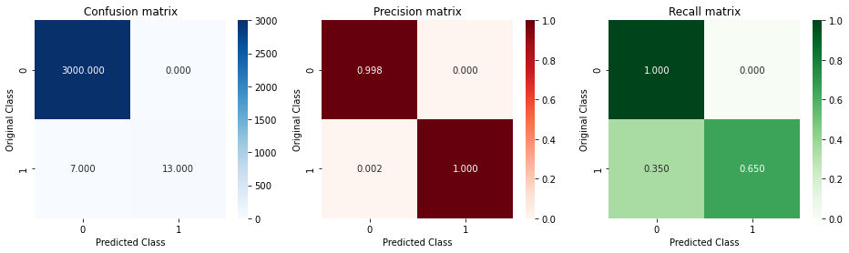

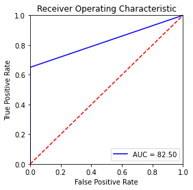

```
KNeighborsClassifier(n_neighbors=15, weights='distance')
```

```python
knn = KNeighborsClassifier(weights='distance', algorithm='auto', n_neighbors=15)
train_model(knn, 'knn')
```

### Observation :

- **KNN**
  - **Accuracy = 99.76%** which is lower than **Logistic Regression Model**.
  - **High Precision but Low Recall.**

## 7.1.5 Decision Tree Model

```python
dtc = DecisionTreeClassifier(class_weight="balanced")
train_model(dtc, 'decision_tree')
```

[output not shown]

```
accuracy_score 99.96688741721854
precision_score 100.0
recall_score 95.0
f1_score 97.43589743589743
roc_auc_score 97.5
confusion_matrix
```

```
DecisionTreeClassifier(class_weight='balanced')
```

### Observation :

- **Decision Tree**
  - **Accuracy = 99.96%** which is equal to **Logistic Regression Model**.
  - **High Precision and High Recall.**
  - **DT and Logistic Regression SkLearn are performance is similar**.

## 7.1.6 Random Forest Model

```
accuracy_score 99.86754966887416
precision_score 100.0
recall_score 80.0
f1_score 88.8888888888889
roc_auc_score 90.0
confusion_matrix
```

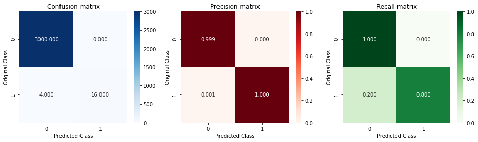

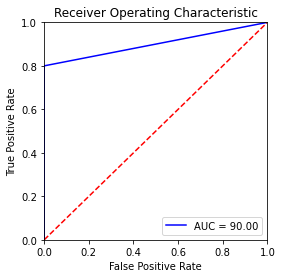

```
RandomForestClassifier(class_weight='balanced')
```

```python
rfc = RandomForestClassifier(n_estimators=100,criterion='gini',class_weight="balanced")
train_model(rfc, 'random_forest')
```

## 7.1.7 XGBoost Model

```python
scale_pos_weight = np.floor(y_train.value_counts()[0]/y_train.value_counts()[1])
xgb = XGBClassifier(scale_pos_weight = scale_pos_weight)
train_model(xgb, 'xgboost')
```

[output not shown]

```
accuracy_score 99.96688741721854
precision_score 100.0
recall_score 95.0
f1_score 97.43589743589743
roc_auc_score 97.5
confusion_matrix
```

```
XGBClassifier(base_score=0.5, booster='gbtree', colsample_bylevel=1,
              colsample_bynode=1, colsample_bytree=1, gamma=0, gpu_id=-1,
              importance_type='gain', interaction_constraints='',
              learning_rate=0.300000012, max_delta_step=0, max_depth=6,
              min_child_weight=1, missing=nan, monotone_constraints='()',
              n_estimators=100, n_jobs=0, num_parallel_tree=1, random_state=0,
              reg_alpha=0, reg_lambda=1, scale_pos_weight=152.0, subsample=1,
              tree_method='exact', validate_parameters=1, verbosity=None)
```

### Observation :

- **XGBOOST**
  - Performing **equivalent** to **Logistic Regression Model** and **Decision Tree**.